# ATAC-seq HOMEWORK

### Visualization

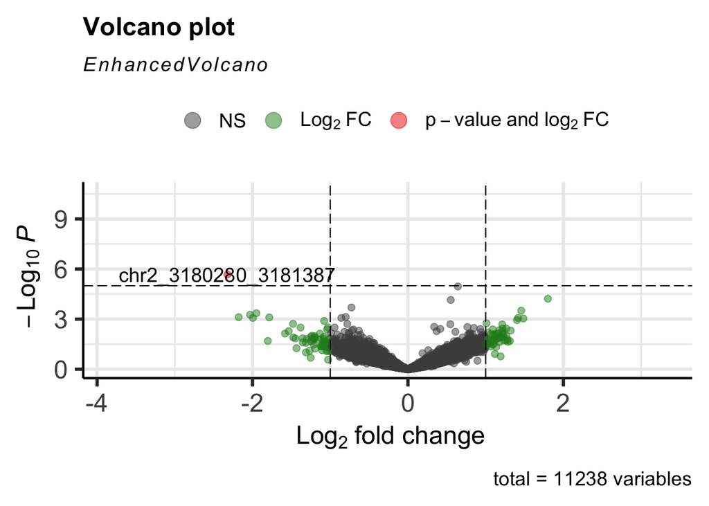

```r
library(EnhancedVolcano)
EnhancedVolcano(res_12h_vs_3h,
                lab = rownames(res_12h_vs_3h),
                x = 'log2FoldChange',
                y = 'pvalue')
```

```r
# There is only 1 significantly differentiated peak between 12h and 3h
# chr2_3180280_3181387 is downregulated in monocyted at 12h

#### Chipseeker: annotation ####

# loading the reference bed file
peaks <- import('reference.bed')

# creating the peak name
peaks$name <- paste0(seqnames(peaks), '_', start(peaks), '_', end(peaks))

# annotating
peakAnno <- annotatePeak(peaks, tssRegion=c(-3000, 3000),
                         TxDb=txdb, annoDb="org.Hs.eg.db")
```

```
## >> preparing features information...      2024-02-12 23:16:13
## >> identifying nearest features...        2024-02-12 23:16:14
## >> calculating distance from peak to TSS...   2024-02-12 23:16:15
## >> assigning genomic annotation...        2024-02-12 23:16:15
## >> adding gene annotation...          2024-02-12 23:16:47
## >> assigning chromosome lengths           2024-02-12 23:16:47
## >> done...                    2024-02-12 23:16:47
```

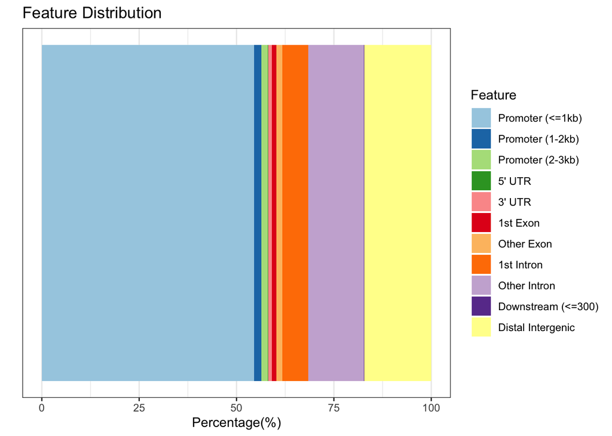

```r
# plotting
plotAnnoBar(peakAnno)
```

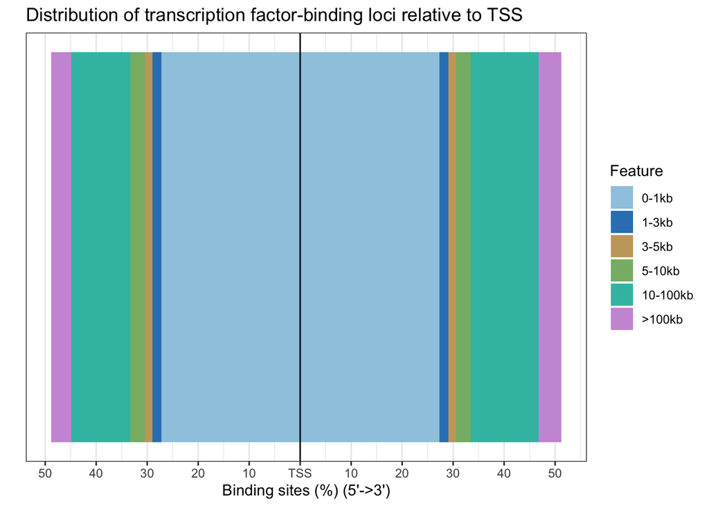

```r
plotDistToTSS(peakAnno)
```

```r
#peaks show usual characteristics for human data, with aprox. 55% of peaks in promoter regions


# characterize the significant peak
peakAnno@anno[peakAnno@anno$name %in% rownames(sig_12h_vs_3h),] # Disatl Intergenic, annotated with EIPR1 gene
```

```
## GRanges object with 1 range and 14 metadata columns:
##       seqnames          ranges strand |                 name     score
##          <Rle>       <IRanges>  <Rle> |          <character> <numeric>
##   [1]     chr2 3180280-3181387      * | chr2_3180280_3181387         0
##              annotation   geneChr geneStart   geneEnd geneLength geneStrand
##             <character> <integer> <integer> <integer>  <integer>  <integer>
##   [1] Distal Intergenic         2   3189325   3194391       5067          2
##            geneId      transcriptId distanceToTSS         ENSEMBL      SYMBOL
##       <character>       <character>     <numeric>     <character> <character>
##   [1]        7260 ENST00000496433.5         13004 ENSG00000032389       EIPR1
##                     GENENAME
##                  <character>
##   [1] EARP complex and GAR..
##   -------
##   seqinfo: 24 sequences from hg38 genome
```

### Integration with RNAseq

```r
##### Load the data

# control panel
raw_data_folder <- 'GSE79044_RAW'
# txt files
txt_files <- file.path(raw_data_folder,
                       dir(raw_data_folder, pattern = '*.txt'))
txt_files
```

```
## [1] "GSE79044_RAW/GSM2084425_3h-Mon-Rep1.processed.txt.gz"
## [2] "GSE79044_RAW/GSM2084426_3h-Mon-Rep2.processed.txt.gz"
## [3] "GSE79044_RAW/GSM2084427_3h-Mon-Rep3.processed.txt.gz"
## [4] "GSE79044_RAW/GSM2084428_6h-Mon-Rep1.processed.txt.gz"
## [5] "GSE79044_RAW/GSM2084429_6h-Mon-Rep2.processed.txt.gz"
## [6] "GSE79044_RAW/GSM2084430_6h-Mon-Rep3.processed.txt.gz"
## [7] "GSE79044_RAW/GSM2084431_12h-Mon-Rep1.processed.txt.gz"
## [8] "GSE79044_RAW/GSM2084432_12h-Mon-Rep2.processed.txt.gz"
## [9] "GSE79044_RAW/GSM2084433_12h-Mon-Rep3.processed.txt.gz"
```

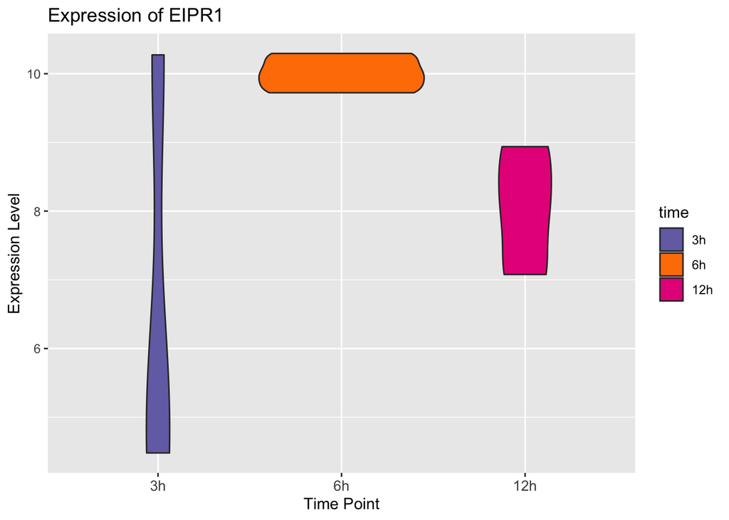

```r
# Loop through the file numbers
for(i in 1:length(txt_files)) {
  # Construct the file name
  file_name <- txt_files[[i]]

  # Read the file
  # Assuming the first row is the header and there's only one column of data
  temp_data <- read.table(file_name)

  # If it's the first file, create the data frame
  if(i == 1) {
    expression_data <- temp_data
  } else {
    # If not the first file, bind the new column to the existing data frame
    # Assuming the rows align across all files
    expression_data <- cbind(expression_data, temp_data[,2])
  }
}


colnames(expression_data) <- expression_data[1,]
expression_data <- expression_data[-1,]
rownames(expression_data) <- expression_data[,1]
expression_data <- expression_data[,-1]
rownames(expression_data) <- gsub("\\..*$", "", rownames(expression_data))

# Make sure that RNA and ATAC data have the same annotations
metadata <- as.data.frame(metadata)
colnames(expression_data) <- rownames(metadata)

# Find the gene of interest annoated in peaks - ENSG00000032389 - EIPR1

# Plot gene expression using violin plots
target_gene <- "ENSG00000032389"
gene_name <- "EIPR1"


# Extract the target gene expression and ensure it's numeric
gene_expression <- as.numeric(expression_data[target_gene, ])

# Create a dataframe for plotting
toPlot <- data.frame(
  sample = colnames(expression_data),
  expression = gene_expression
)

# Merge this data with 'metadata' to get the time information for each sample
toPlot <- merge(toPlot, metadata, by.x = "sample", by.y = "row.names")

# Convert 'time' to a factor with specified levels
toPlot$time <- factor(toPlot$time, levels = c("3h", "6h", "12h"))


time <- factor(metadata$time, levels=c("3h","6h", "12h"))
color_time <- c("#7570B3", "#FF7F00", "#E7298A")

# Plotting
ggplot(toPlot, aes(x = time, y = expression, fill = time)) +
  geom_violin() +
  scale_fill_manual(values = color_time) +
  ggtitle(paste("Expression of", gene_name)) +
  xlab("Time Point") +
  ylab("Expression Level") +
  theme(axis.text.x = element_text(size = 10, angle = 0))
```

```r
# Repeat plot for ATACseq

# Plot gene expression using violin plots
rownames(sig_12h_vs_3h)
```

```
## [1] "chr2_3180280_3181387"
```

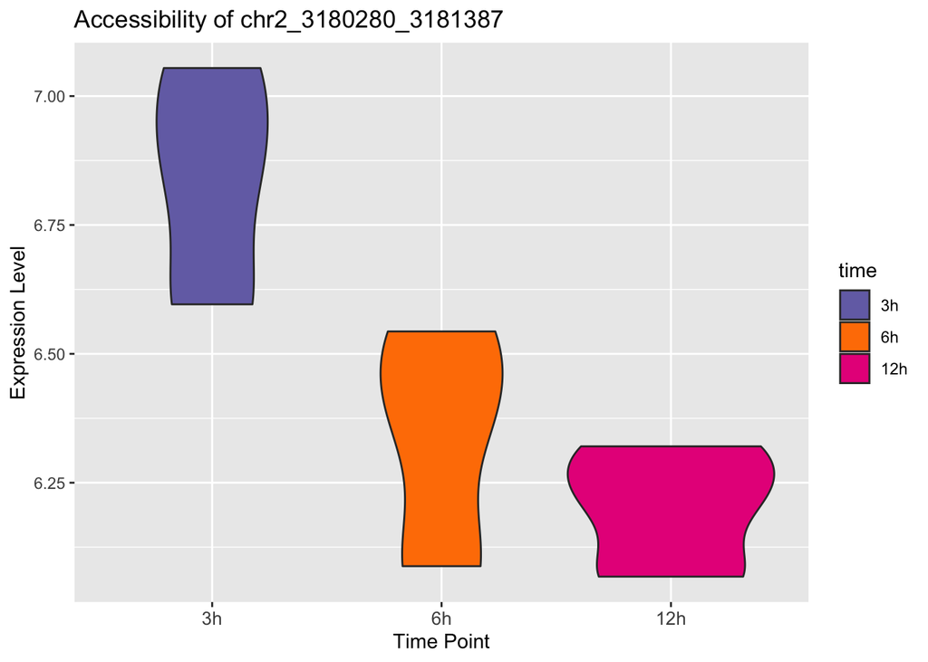

```r
target_peak <- rownames(sig_12h_vs_3h)
peak_name <- rownames(sig_12h_vs_3h)

# Extract the target gene expression and ensure it's numeric
peak_expression <- assay(vsd_f)[peak_name,]

# Create a dataframe for plotting
toPlot <- data.frame(
  sample = colnames(count_matrix),
  expression = peak_expression
)

# Merge this data with 'metadata' to get the time information for each sample
toPlot <- merge(toPlot, metadata, by.x = "sample", by.y = "row.names")

# Convert 'time' to a factor with specified levels
toPlot$time <- factor(toPlot$time, levels = c("3h", "6h", "12h"))

# Plotting
ggplot(toPlot, aes(x = time, y = expression, fill = time)) +
  geom_violin() +
  scale_fill_manual(values = color_time) +
  ggtitle(paste("Accessibility of", peak_name)) +
  xlab("Time Point") +
  ylab("Expression Level") +
  theme(axis.text.x = element_text(size = 10, angle = 0))
```

The peak is down-regulated with the time from 3h to 12h. We can see a similar trend in the annotated gene to that region - EIPR1, except a huge varaibility of expression at 3h, which makes it hard to come to any conclusions.

In general, comapring the first 3 time points of the monocyted differentiation, is not enough to make any conclusions, and we should compare further timepoints.

### ATACseq heatmap

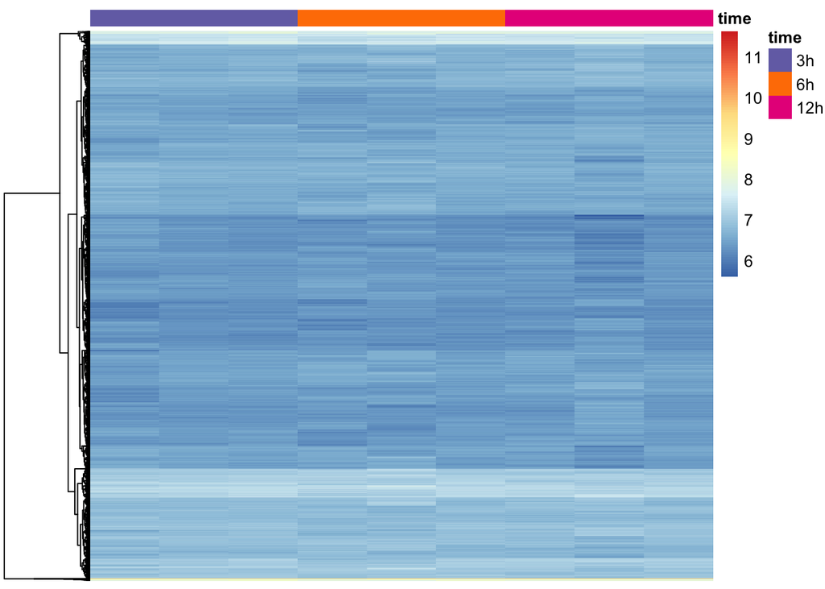

```r
# heatmap
library("pheatmap")

# heatmap annotation
df <- as.data.frame(colData(data_DESeq2_F)[,c("time")])
colnames(df) <- "time"

color_time <- c("#7570B3", "#FF7F00", "#E7298A")
names(color_time) <- c("3h","6h", "12h")

# Define your own colors
group_df = data.frame(vsd_f$time)
rownames(group_df) <- colnames(vsd_f)
colnames(group_df) <- "time"

annotation_df <- data.frame(GroupColor = color_time[vsd$time])

my_colors <- list(color_time)
names(my_colors) <- "time"

toPlot <- assay(vsd_f)

# Plot
pheatmap(toPlot, cluster_rows=T, show_rownames=F, show_colnames = F,
         cluster_cols=F, annotation_col = group_df,annotation_colors = my_colors,
         labels_row = NULL, fontsize_row = 6)
```

As we can see visually through the heatmap, all peaks have very similar accessibility across different time points.